# Análise dos dados da Netflix

Ketlin Hoffmam

2021-05-04

- O banco de dados contém informações de 7787 títulos de filmes / séries da Netflix. As variáveis estão listadas a seguir:
- Tipo: a categoria do programa, pode ser um filme ou uma série;
- Título: nome da série ou filme;
- Diretor: nome do (s) diretor (es);
- Elenco: nome dos atores;
- País: nome dos países em que o título está disponível para assistir na Netflix;
- Data adição: data em que o título foi adicionado ao Netflix;
- Ano de lançamento: ano de lançamento do filme ou série;
- Classificação: classificação indicativa do título;
- Duração: tempo de duração da série ou filme;
- Listado em: gênero da série ou filme;
- Descrição: algum texto que descreve a série ou filme;

+ Sobre a categoria do programa, temos 69% de filmes e 31% de séries.

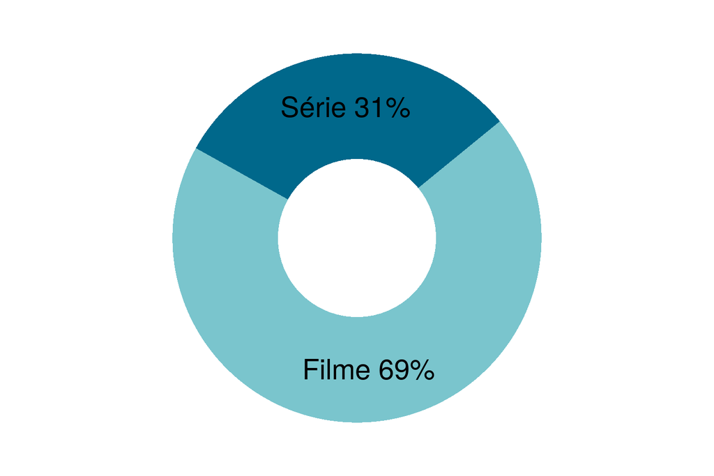

```r
netflixdata2<-netflixdata

netflixdata2$type<-as.character(netflixdata2$type)
 netflixdata2$type[netflixdata2$type == "Movie"] <- "Filme"
  netflixdata2$type[netflixdata2$type == "TV Show"] <- "Série"

grafico_pizza<-
netflixdata2 %>%
  select(type) %>%
group_by(type) %>%
  count() %>%
ungroup()%>%
  arrange(desc(type)) %>%
  mutate(percentage = round(n/sum(n),2)*100,
         lab.pos = cumsum(percentage)-.5*percentage) %>%
  filter(n>1) %>%
  select(type, percentage, lab.pos) %>%
  setNames(c("Tipo", "percentage", "lab.pos"))


ggplot(data = grafico_pizza,
       aes(x = 2, y = percentage, fill = Tipo))+
geom_bar(stat = "identity", fill = c( "deepskyblue4","cadetblue3"))+
  coord_polar("y", start = 200) +
  geom_text(aes(y = lab.pos, label = paste(Tipo, " ",percentage,"%", sep = "")), size = 6) +
    theme_void() +
  xlim(0.875,2.5)
```

- Top 10 Diretores

```r
netflixdata %>%
  select(director) %>%
  separate(col=director,
           into = paste('resp',1:11), sep=', ') %>%
select(starts_with("resp")) %>%
   gather(key='id',value='respostas') %>%
  group_by(respostas) %>%
  count() %>%
arrange(desc(n)) %>%
  na.omit(n) %>%
filter(respostas != "") %>%
  as.data.frame() %>%
  top_n(10) %>%
setNames(c("Diretor", "Quantidade de filmes / Séries")) %>%
   kable(row.names = F) %>%
  kable_styling()
```

| Diretor | Quantidade de filmes / Séries |
| --- | --- |
| Jan Suter | 21 |
| Raúl Campos | 19 |
| Marcus Raboy | 16 |
| Jay Karas | 15 |
| Cathy Garcia-Molina | 13 |
| Jay Chapman | 12 |
| Martin Scorsese | 12 |
| Youssef Chahine | 12 |
| Steven Spielberg | 10 |
| Anurag Kashyap | 9 |
| David Dhawan | 9 |
| Shannon Hartman | 9 |

- Nomes mais evidentes nos elencos dos títulos disponíveis na plataforma.

```r
netflixdata %>%
  select(cast) %>%
  separate(col=cast,
           into = paste('resp',1:15), sep=', ') %>%
select(starts_with("resp")) %>%
   gather(key='id',value='respostas') %>%
  group_by(respostas) %>%
  count() %>%
arrange(desc(n)) %>%
  na.omit(n) %>%
filter(respostas != "") %>%
  as.data.frame() %>%
  top_n(9) %>%
setNames(c("Elenco", "Quantidade de filmes / Séries")) %>%
    kable(row.names = F) %>%
  kable_styling()
```

| Elenco | Quantidade de filmes / Séries |
| --- | --- |
| Anupam Kher | 42 |
| Shah Rukh Khan | 35 |
| Naseeruddin Shah | 30 |
| Om Puri | 30 |
| Akshay Kumar | 29 |
| Amitabh Bachchan | 27 |
| Boman Irani | 27 |
| Paresh Rawal | 27 |
| Takahiro Sakurai | 27 |

- Abaixo podemos ver as regiões que contém mais de 100 filmes disponíveis para visualização na plataforma. Os Estados Unidos é o país que tem mais filmes disponíveis.

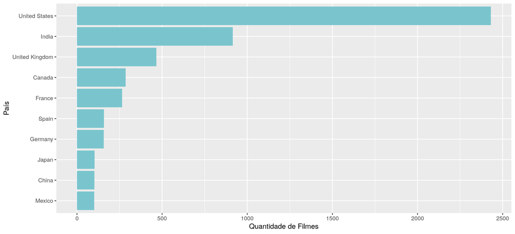

```r
netflixdata %>%
  select(country, type) %>%
  filter(type =="Movie") %>%
  separate(col=country,
           into = paste('resp',1:30), sep=', ') %>%
select(starts_with("resp")) %>%
   gather(key='id',value='respostas') %>%
  group_by(respostas) %>%
  count() %>%
arrange(desc(n)) %>%
  na.omit(n) %>%
filter(respostas != "") %>%
  as.data.frame()%>%
  top_n(10) %>%
setNames(c("Região", "Quantidade de filmes")) %>%
  ggplot(aes(x = reorder(Região,`Quantidade de filmes`), y = `Quantidade de filmes`)) +
  geom_bar(stat = 'identity', colour = "NA", fill = "cadetblue3") +
  labs(x = "País", y = "Quantidade de Filmes")  +
  coord_flip()
```

- Top 10 países com mais números de séries disponíveis para assistir.

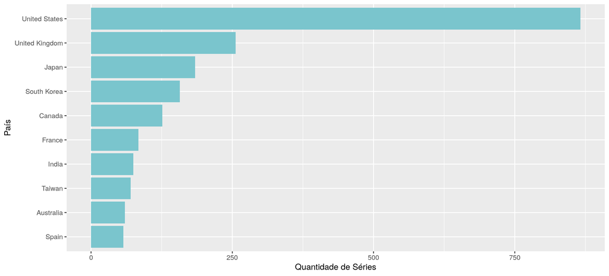

```r
netflixdata %>%
  select(country, type) %>%
  filter(type =="TV Show") %>%
  separate(col=country,
           into = paste('resp',1:20), sep=', ') %>%
select(starts_with("resp")) %>%
   gather(key='id',value='respostas') %>%
  group_by(respostas) %>%
  count() %>%
arrange(desc(n)) %>%
  na.omit(n) %>%
filter(respostas != "") %>%
  as.data.frame()%>%
  top_n(10) %>%
setNames(c("Região", "Quantidade de Séries")) %>%
  setNames(c("Região", "Quantidade de Séries")) %>%
  ggplot(aes(x = reorder(Região,`Quantidade de Séries`), y = `Quantidade de Séries`)) +
  geom_bar(stat = 'identity', colour = "NA", fill = "cadetblue3") +
  labs(x = "País", y = "Quantidade de Séries")  +
  coord_flip()
```

- Quanto tempo o Netflix leva para colocar um filme, após o seu lançamento? Para isso, vamos excluir os títulos que tem data de lançamento menor do que a existência da Netflix (pode ser verificada a partir da primeira inclusão. Podemos ver que foi em 2008), a fim de não influenciar a conclusão de uma forma errônea.

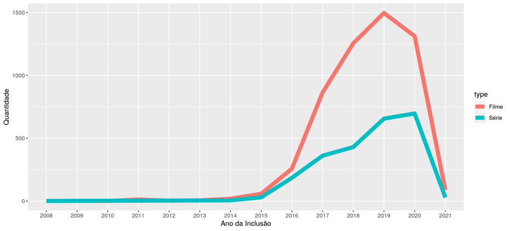

```r
netflixdata2 %>%
  select(date_added, type) %>%
  separate(col=date_added,
           into = paste('resp',1:2), sep=', ') %>%
  select(`resp 2`, type) %>%
  # filter(type == "Movie") %>%
  group_by(`resp 2`) %>%
  count(type) %>%
  na.omit(n) %>%
  arrange(`resp 2`) %>%
 ggplot(aes(x = `resp 2` , y = n, group = type, colour = type)) +
  labs(x = "Ano da Inclusão", y = "Quantidade")  +
  geom_line(size = 3)
```

- Qual a quantidade de filmes é adicionado no mesmo ano de lançamento? A resposta é 35%. Já 83% dos filmes são adicionados com até 5 anos de diferença entre as datas.

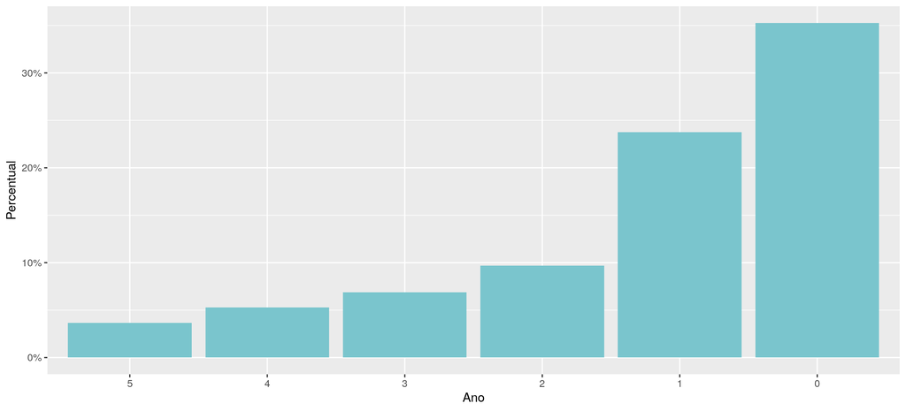

```r
a<-netflixdata %>%
  select(release_year, type) %>%
  filter(type == "Movie")

 b<- netflixdata %>%
  select(date_added, type) %>%
   filter(type == "Movie") %>%
  separate(col=date_added,
           into = paste('resp',1:2), sep=', ') %>%
  select(`resp 2`)

 c<-bind_cols(a,b) %>%
     filter(release_year >= 2008)

 c %>%
  mutate(release_year = as.numeric(release_year),
         `resp 2` = as.numeric(`resp 2`),
         dif = (`resp 2`-release_year)) %>%
   group_by(dif) %>%
   count() %>%
   filter(dif != -3) %>%
   filter(dif != -2 ) %>%
   filter(dif != -1) %>%
   as.data.frame() %>%
   mutate(total = sum(n)) %>%
   mutate( Percentual = (n / total)) %>%
   as.data.frame() %>%
   top_n(6, ((n))) %>%
   mutate(total_perc = sum(Percentual)) %>%
   select(dif, Percentual) %>%
    ggplot(aes(x = reorder(dif,Percentual), y = Percentual)) +
  geom_bar(stat = 'identity', colour = "NA", fill = "cadetblue3") +
  labs(x = "Ano", y = "Percentual")  +
   scale_y_continuous(labels = scales::percent_format())
```

- 53 % das séries são adicionados no mesmo ano de lançamento. Já 87% delas são adicionados com até 5 anos de diferença entre as datas.

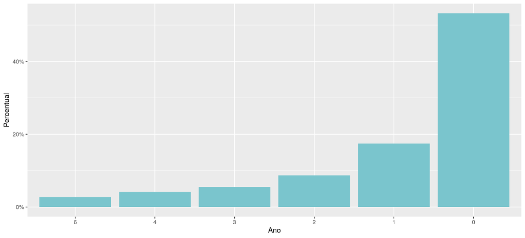

```r
a<-netflixdata %>%
  select(release_year, type) %>%
  filter(type == "TV Show")

 b<- netflixdata %>%
  select(date_added, type) %>%
   filter(type == "TV Show") %>%
  separate(col=date_added,
           into = paste('resp',1:2), sep=', ') %>%
  select(`resp 2`)

 c<-bind_cols(a,b)%>%
     filter(release_year >= 2008)

 c %>%
  mutate(release_year = as.numeric(release_year),
         `resp 2` = as.numeric(`resp 2`),
         dif = (`resp 2`-release_year)) %>%
   group_by(dif) %>%
   count() %>%
   filter(dif != -3) %>%
   filter(dif != -2 ) %>%
   filter(dif != -1) %>%
   arrange((dif)) %>%
   as.data.frame() %>%
   mutate(total = sum(n)) %>%
   mutate( Percentual = (n / total)) %>%
   top_n(6) %>%
   mutate(total_perc = sum(Percentual)) %>%
   select(dif, Percentual) %>%
    ggplot(aes(x = reorder(dif,Percentual), y = Percentual)) +
  geom_bar(stat = 'identity', colour = "NA", fill = "cadetblue3") +
  labs(x = "Ano", y = "Percentual")  +
   scale_y_continuous(labels = scales::percent_format())
```

- As duração das séries, variam de 1 até 15 temporadas, e os dados seguem uma distribuição exponencial.

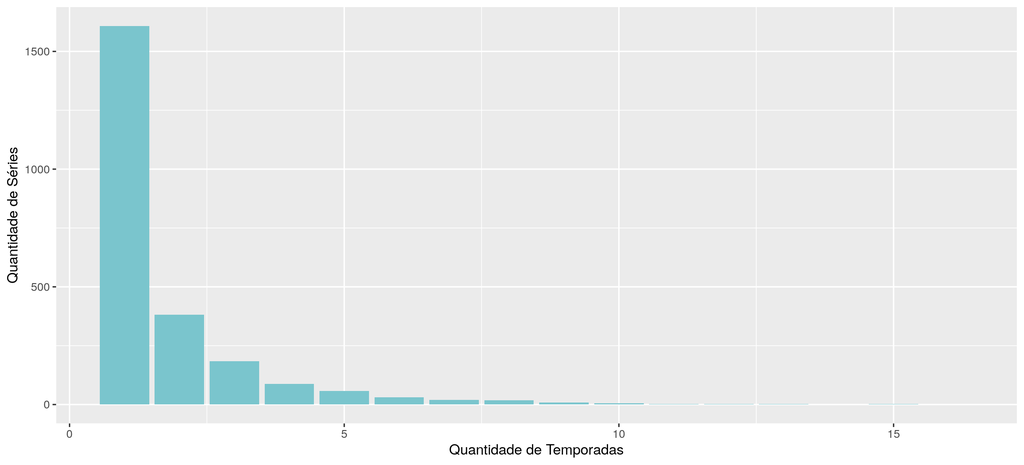

```r
# counts
netflixdata %>%
  select(duration, type) %>%
  filter(type == "TV Show") %>%
  separate(col=duration,
           into = paste('Season',1:2), sep=' ') %>%
  setNames(c("Season", "Season2", "Type")) %>%
  mutate(Season = as.numeric(Season)) %>%
ggplot(aes(x=`Season`)) +
  geom_bar(fill = "cadetblue3")+
    labs(x = "Quantidade de Temporadas", y = "Quantidade de Séries")
```

- A distribuição da duração dos filmes segue uma distribuição normal.

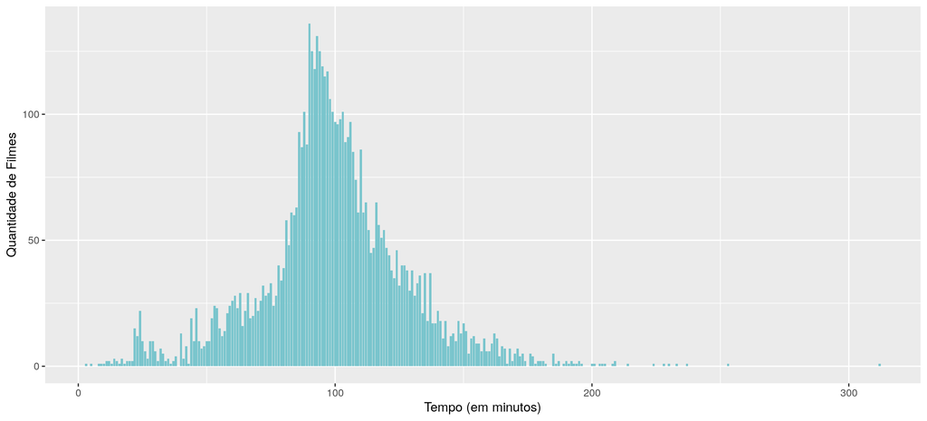

```r
# counts
netflixdata %>%
  select(duration, type) %>%
  filter(type == "Movie") %>%
  separate(col=duration,
           into = paste('Min',1:2), sep=' ') %>%
  mutate(`Tempo` = as.numeric(`Min 1`)) %>%
ggplot(aes(x=`Tempo`)) +
  geom_bar(fill = "cadetblue3")+
  labs(x = "Tempo (em minutos)", y = "Quantidade de Filmes")
```

- 90% dos filmes tem de 52 a 148 minutos de duração. O tempo médio de duração é de 99 minutos (cerca de 1 hora e meia).

```r
data2<- netflixdata %>%
  select(duration, type) %>%
  filter(type == "Movie") %>%
  separate(col=duration,
           into = paste('Min',1:2), sep=' ') %>%
  mutate(`Tempo` = as.numeric(`Min 1`))
quantile(data2$Tempo, probs = 0.05)
```

```
## 5%
## 52
```

```r
quantile(data2$Tempo, probs = 0.95)
```

```
## 95%
## 148
```

```r
mean(data2$Tempo)
```

```
## [1] 99.30798
```

```r
# counts
a<-netflixdata %>%
  select(duration, type) %>%
  filter(type == "Movie") %>%
  separate(col=duration,
           into = paste('Min',1:2), sep=' ') %>%
  mutate(`Tempo` = as.numeric(`Min 1`)) %>%
  select(Tempo) %>%
  top_n(5, desc(Tempo))

b<-netflixdata %>%
  select(duration, type) %>%
  filter(type == "Movie") %>%
  separate(col=duration,
           into = paste('Min',1:2), sep=' ') %>%
  mutate(`Tempo` = as.numeric(`Min 1`)) %>%
  select(Tempo) %>%
  arrange(desc(Tempo)) %>%
  as.data.frame() %>%
  top_n(5) %>%
   kable(row.names = F) %>%
  kable_styling()
```

```r
# counts
df_filme<-netflixdata %>%
  select(date_added, type) %>%
  filter(type == "Movie") %>%
  separate(col=date_added,
           into = paste('Min',1:2), sep=', ') %>%
  select(`Min 2`, type) %>%
  group_by(`Min 2`) %>%
  count() %>%
  arrange(desc(`Min 2`)) %>%
  as.data.frame() %>%
  top_n(5) %>%
  setNames(c("Ano", 'Número'))

 x<-"Filme"
 x2<- rep(x, 5)
 df_filme[,"Tipo"] <- x2
```

- Abaixo temos informações sobre a quantidade de séries incluídas na plataforma nos ultimos 5 anos.

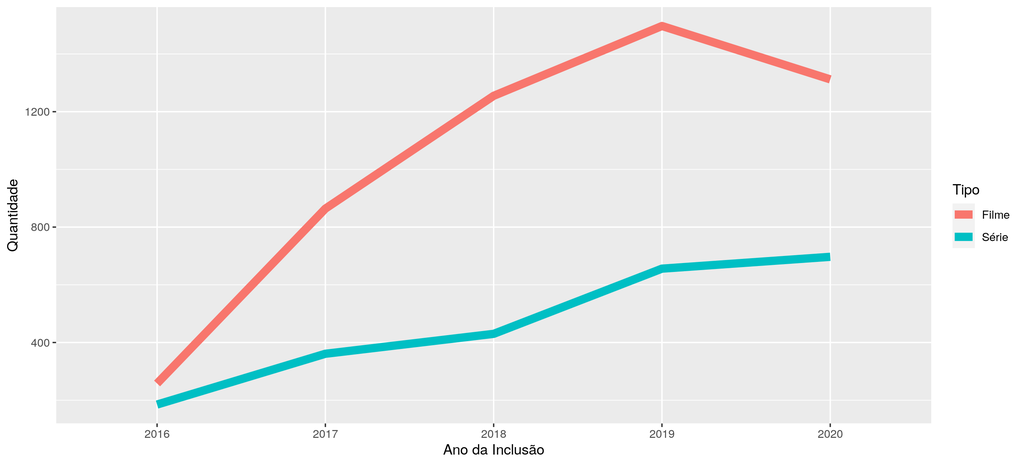

```r
df_serie<-netflixdata %>%
  select(date_added, type) %>%
  filter(type == "TV Show") %>%
  separate(col=date_added,
           into = paste('Min',1:2), sep=', ') %>%
  select(`Min 2`, type) %>%
  group_by(`Min 2`) %>%
  count() %>%
  arrange(desc(`Min 2`)) %>%
   as.data.frame() %>%
  top_n(5) %>%
  setNames(c("Ano", 'Número'))

x<-"Série"
 x1<- rep(x, 5)
   df_serie[,"Tipo"] <- x1

   df_final<-bind_rows(df_serie, df_filme)

     df_final %>%
       ggplot(aes(x=`Ano`, y=`Número`, group = Tipo, colour = Tipo)) +
  labs(x = "Ano da Inclusão", y = "Quantidade")  +
  geom_line(size = 3)
```

- Top 5 filmes por data de lançamento e ano. Temos mais quantidade de filmes lançados em 2017 na plataforma do que lançados em outros anos.

```r
netflixdata %>%
  select(release_year, type) %>%
  filter(type == "Movie") %>%
  group_by(release_year) %>%
  count() %>%
  arrange(desc(n
               )) %>%
  as.data.frame() %>%
  top_n(5) %>%
    setNames(c("Ano de Lancamento", 'Quantidade de filmes incluídos na plataforma')) %>%
    kable(row.names = F) %>%
  kable_styling()
```

| Ano de Lancamento | Quantidade de filmes incluídos na plataforma |
| --- | --- |
| 2017 | 744 |
| 2018 | 734 |
| 2016 | 642 |
| 2019 | 582 |
| 2020 | 411 |

```r
# counts
netflixdata %>%
  select(date_added, type) %>%
  filter(type == "TV Show") %>%
  separate(col=date_added,
           into = paste('Min',1:2), sep=', ') %>%
  select(`Min 2`, type) %>%
  group_by(`Min 2`) %>%
  count() %>%
  arrange(desc(n)) %>%
  as.data.frame() %>%
  top_n(5) %>%
  setNames(c("Ano de Lancamento", 'Quantidade de Séries incluídas na plataforma')) %>%
  kable(row.names = F) %>%
  kable_styling()
```

| Ano de Lancamento | Quantidade de Séries incluídas na plataforma |
| --- | --- |
| 2020 | 697 |
| 2019 | 656 |
| 2018 | 430 |
| 2017 | 361 |
| 2016 | 185 |